# Homework 3

Author

Oscar Lam

## Loading in Data

```r
library(tidyverse)
library(tidytext)
library(ggplot2)

pubmed <- read_csv("pubmed.csv")
```

# Text Mining

## Question 1

```r
pubmed %>%
  count(term) %>%
  arrange(desc(n))
```

```
# A tibble: 5 × 2
  term                n
  <chr>           <int>
1 covid             981
2 prostate cancer   787
3 preeclampsia      780
4 cystic fibrosis   376
5 meningitis        317
```

Covid → n = 981

Prostate Cancer → n = 787

Preeclampsia → n = 780

Cystic fibrosis → n = 376

Meningitis → n = 317

### Tokenise & count the abstract:

```r
pubmed_tokens <- pubmed %>%
  unnest_tokens(word, abstract)

pubmed_tokens %>%
  count(word, sort = TRUE)
```

```
# A tibble: 20,567 × 2
   word      n
   <chr> <int>
 1 the   28126
 2 of    24760
 3 and   19993
 4 in    14653
 5 to    10920
 6 a      8245
 7 with   8038
 8 covid  7275
 9 19     7080
10 is     5649
# ℹ 20,557 more rows
```

8 out of the top 10 ranked words are all filler words as expected since they’re the most common words in English. The other two being “covid” and “19” also makes sense since COVID is the most counted abstract.

### 5 most common tokens per search term

```r
top_5_per_term <- pubmed_tokens %>%
  count(term, word, sort= TRUE) %>%
  group_by(term) %>%
  slice_max(n, n=5) %>%
  ungroup()

knitr::kable(top_5_per_term)
```

| term | word | n |
| --- | --- | --- |
| covid | the | 9741 |
| covid | of | 7668 |
| covid | covid | 7275 |
| covid | 19 | 7035 |
| covid | and | 6861 |
| cystic fibrosis | the | 2677 |
| cystic fibrosis | of | 2304 |
| cystic fibrosis | and | 1777 |
| cystic fibrosis | in | 1497 |
| cystic fibrosis | to | 1011 |
| meningitis | the | 2489 |
| meningitis | of | 2269 |
| meningitis | and | 1683 |
| meningitis | in | 1322 |
| meningitis | a | 830 |
| preeclampsia | the | 7119 |
| preeclampsia | of | 6837 |
| preeclampsia | and | 5255 |
| preeclampsia | in | 3869 |
| preeclampsia | to | 2651 |
| prostate cancer | the | 6100 |
| prostate cancer | of | 5682 |
| prostate cancer | and | 4417 |
| prostate cancer | cancer | 3840 |
| prostate cancer | prostate | 3832 |

## Question 2

### Change after removing stop words

```r
pubmed_tokens %>%
  anti_join(stop_words, by = "word") %>%
  count(word, sort=TRUE)
```

```
# A tibble: 19,978 × 2
   word             n
   <chr>        <int>
 1 covid         7275
 2 19            7080
 3 patients      4674
 4 cancer        3999
 5 prostate      3832
 6 disease       2574
 7 pre           2165
 8 eclampsia     2005
 9 preeclampsia  1863
10 treatment     1841
# ℹ 19,968 more rows
```

Yes, removing stop words changes what tokens appear as the most frequent. The top 10 are now words that are associated with medical papers.

### Top 5 most common tokens after removing stop words

```r
pubmed_tokens %>%
  anti_join(stop_words, by = "word") %>%
  count(word, sort=TRUE) %>%
  slice_max(n, n=5)
```

```
# A tibble: 5 × 2
  word         n
  <chr>    <int>
1 covid     7275
2 19        7080
3 patients  4674
4 cancer    3999
5 prostate  3832
```

Top 5 most common tokens after removing stop words are covid, 19, patients, cancer, prostate.

## Question 3

### Tokenise abstracts into bigrams & find top 10 most common bigrams

```r
top10_bigrams <- pubmed %>%
  unnest_tokens(bigram, abstract, token= "ngrams", n=2) %>%
  count(bigram, sort= TRUE) %>%
  slice_max(n, n=10)

top10_bigrams
```

```
# A tibble: 10 × 2
   bigram              n
   <chr>           <int>
 1 covid 19         6969
 2 of the           3883
 3 in the           3418
 4 prostate cancer  3222
 5 pre eclampsia    1854
 6 patients with    1587
 7 of covid         1519
 8 and the          1154
 9 to the           1061
10 of prostate       870
```

### Visualise top 10 bigrams

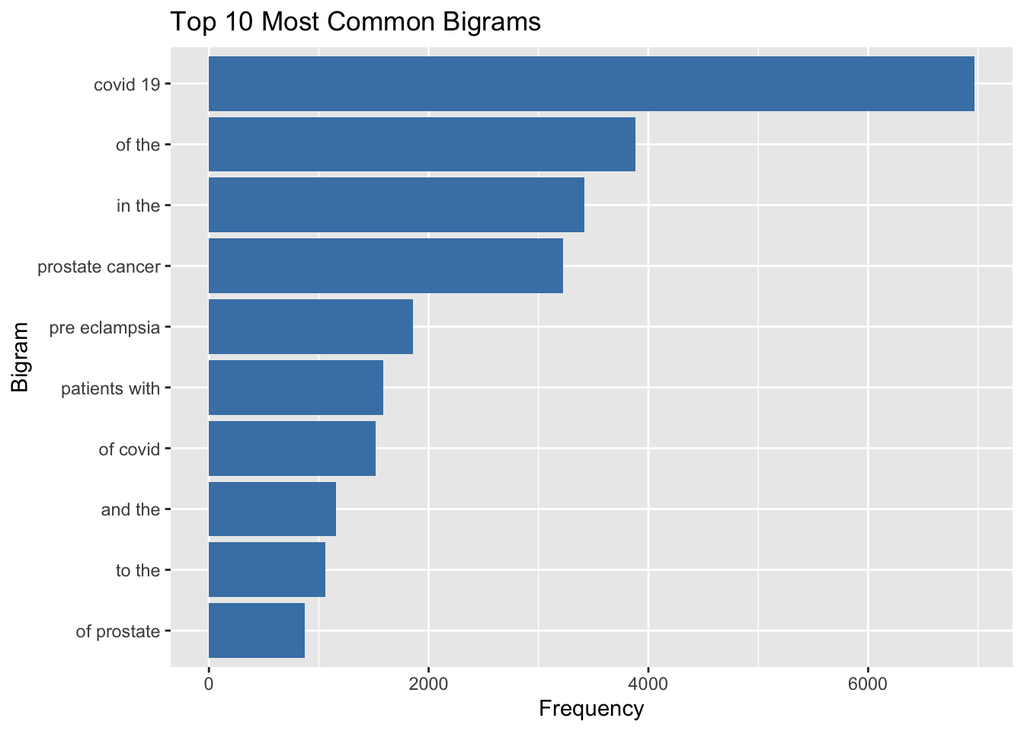

```r
ggplot(top10_bigrams, aes(x= reorder(bigram, n), y= n)) +
  geom_col(fill= "steelblue") +
  coord_flip() +
  labs(title = "Top 10 Most Common Bigrams",
       x= "Bigram",
       y= "Frequency")
```

Without removing stop words, top 10 bigrams still filled with some stop words (eg of the / in the / and the).

## Question 4

### Top 5 TF-IDF value for each search term

```r
top5_TFIDF <- pubmed_tokens %>%
  count(term, word, sort= TRUE) %>%
  bind_tf_idf(word, term, n) %>%
  group_by(term) %>%
  slice_max(tf_idf, n = 5)

knitr::kable(top5_TFIDF)
```

| term | word | n | tf | idf | tf_idf |
| --- | --- | --- | --- | --- | --- |
| covid | covid | 7275 | 0.0371050 | 1.6094379 | 0.0597183 |
| covid | pandemic | 800 | 0.0040803 | 1.6094379 | 0.0065670 |
| covid | coronavirus | 647 | 0.0032999 | 1.6094379 | 0.0053110 |
| covid | sars | 372 | 0.0018973 | 1.6094379 | 0.0030536 |
| covid | cov | 334 | 0.0017035 | 1.6094379 | 0.0027417 |
| cystic fibrosis | cf | 625 | 0.0127188 | 0.9162907 | 0.0116541 |
| cystic fibrosis | fibrosis | 867 | 0.0176435 | 0.5108256 | 0.0090127 |
| cystic fibrosis | cystic | 862 | 0.0175417 | 0.5108256 | 0.0089608 |
| cystic fibrosis | cftr | 86 | 0.0017501 | 1.6094379 | 0.0028167 |
| cystic fibrosis | sweat | 83 | 0.0016891 | 1.6094379 | 0.0027184 |
| meningitis | meningitis | 429 | 0.0091942 | 1.6094379 | 0.0147974 |
| meningitis | meningeal | 219 | 0.0046935 | 1.6094379 | 0.0075539 |
| meningitis | pachymeningitis | 149 | 0.0031933 | 1.6094379 | 0.0051394 |
| meningitis | csf | 206 | 0.0044149 | 0.9162907 | 0.0040453 |
| meningitis | meninges | 106 | 0.0022718 | 1.6094379 | 0.0036562 |
| preeclampsia | eclampsia | 2005 | 0.0142784 | 1.6094379 | 0.0229802 |
| preeclampsia | preeclampsia | 1863 | 0.0132672 | 1.6094379 | 0.0213527 |
| preeclampsia | pregnancy | 969 | 0.0069006 | 0.5108256 | 0.0035250 |
| preeclampsia | maternal | 797 | 0.0056757 | 0.5108256 | 0.0028993 |
| preeclampsia | gestational | 191 | 0.0013602 | 1.6094379 | 0.0021891 |
| prostate cancer | prostate | 3832 | 0.0311890 | 1.6094379 | 0.0501967 |
| prostate cancer | androgen | 305 | 0.0024824 | 1.6094379 | 0.0039953 |
| prostate cancer | psa | 282 | 0.0022952 | 1.6094379 | 0.0036940 |
| prostate cancer | prostatectomy | 215 | 0.0017499 | 1.6094379 | 0.0028164 |
| prostate cancer | castration | 148 | 0.0012046 | 1.6094379 | 0.0019387 |

Compared to the result from question 1, by ranking it using TF-IDF value, the result is that the words are all domain-specific medical terminology instead of stop words. TF-IDF filters out common stop words by giving them a lower IDF score and highlights words that are specific to that term.

# Sentiment Analysis

## Load in packages

```r
library(textdata)
nrc <- get_sentiments("nrc")
afinn <- get_sentiments("afinn")
```

## Question 5

### Most common sentiment for each search term using NRC lexicon

```r
pubmed_nrc <- pubmed_tokens %>%
  inner_join(nrc, by= "word")
most_common_sentiment <- pubmed_nrc %>%
  count(term, sentiment, sort= TRUE) %>%
  group_by(term) %>%
  slice_max(n, n=1)

most_common_sentiment
```

```
# A tibble: 5 × 3
# Groups:   term [5]
  term            sentiment     n
  <chr>           <chr>     <int>
1 covid           positive   9874
2 cystic fibrosis positive   2747
3 meningitis      negative   2109
4 preeclampsia    positive   8014
5 prostate cancer negative   8918
```

Most common sentiment for covid is positive; cystic fibrosis is positive; meningitis is negative; preeclampsia is positive; prostate cancer is negative.

### Removing “positive” and “negative”

```r
 pubmed_nrc %>%
  filter(!sentiment %in% c("positive", "negative")) %>%
  count(term, sentiment, sort= TRUE) %>%
   group_by(term) %>%
  slice_max(n, n=1)
```

```
# A tibble: 5 × 3
# Groups:   term [5]
  term            sentiment        n
  <chr>           <chr>        <int>
1 covid           fear          7730
2 cystic fibrosis disgust       1714
3 meningitis      fear          1510
4 preeclampsia    anticipation  4780
5 prostate cancer fear          8118
```

By removing positive and negative, it makes more sense about how people perceive each term. Positive for COVID becomes fear; positive for cystic fibrosis becomes disgust.

## Question 6

### AFINN lexicon

```r
abstract_sentiment <- pubmed %>%
  mutate(abstract_id= row_number()) %>%
  unnest_tokens(word, abstract) %>%
  inner_join(afinn, by= "word") %>%
  group_by(abstract_id, term) %>%
  summarise(avg_sentiment= mean(value), .groups= "drop")

sentiment_summ <- abstract_sentiment %>%
  group_by(term) %>%
  summarise(mean_sentiment= mean(avg_sentiment))

sentiment_summ
```

```
# A tibble: 5 × 2
  term            mean_sentiment
  <chr>                    <dbl>
1 covid                   -0.147
2 cystic fibrosis          0.322
3 meningitis              -0.163
4 preeclampsia            -0.121
5 prostate cancer         -0.239
```

### Visualise

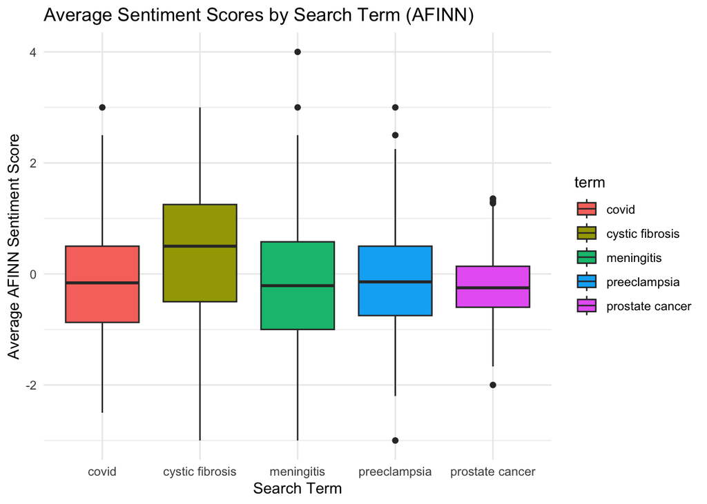

```r
ggplot(abstract_sentiment, aes(x= term, y= avg_sentiment, fill= term)) +
  geom_boxplot() +
  labs(title = "Average Sentiment Scores by Search Term (AFINN)",
       x = "Search Term",
       y = "Average AFINN Sentiment Score") +
  theme_minimal()
```

#### “Are any search terms noticeably different from the others?”

From the boxplot, cystic fibrosis is noticeably different from the other because cystic fibrosis has a positive average AFINN score compared to the rest which are all negative.